# Machine Learning - Course Project

Momoko Price

7/2/2017

# Course Project: Classifying Weight-Lifting Movement with Barbells

In this project, our goal is to use data from accelerometers on the belt, forearm, arm, and dumbell of 6 participants to identify the class of movement they are performing. Here are the 5 classes of movement, as described in the [original research paper](http://groupware.les.inf.puc-rio.br/har):

A - Correct movement B - Throwing elbows to the front C - Lifting only halfway D - Lowering only halfway E - Throwing hips to the front

### STEP 0: LOAD REQUIRED LIBRARIES & DATA

### Step 1: Clean the Data

First we take a look at the data to see what we’re dealing with:

```r
dim(raw_train)
```

```
## [1] 19622   160
```

```r
str(raw_train)
```

```
## 'data.frame':    19622 obs. of  160 variables:
##  $ X                       : int  1 2 3 4 5 6 7 8 9 10 ...
##  $ user_name               : Factor w/ 6 levels "adelmo","carlitos",..: 2 2 2 2 2 2 2 2 2 2 ...
##  $ raw_timestamp_part_1    : int  1323084231 1323084231 1323084231 1323084232 1323084232 1323084232 1323084232 1323084232 1323084232 1323084232 ...
##  $ raw_timestamp_part_2    : int  788290 808298 820366 120339 196328 304277 368296 440390 484323 484434 ...
##  $ cvtd_timestamp          : Factor w/ 20 levels "02/12/2011 13:32",..: 9 9 9 9 9 9 9 9 9 9 ...
##  $ new_window              : Factor w/ 2 levels "no","yes": 1 1 1 1 1 1 1 1 1 1 ...
##  $ num_window              : int  11 11 11 12 12 12 12 12 12 12 ...
##  $ roll_belt               : num  1.41 1.41 1.42 1.48 1.48 1.45 1.42 1.42 1.43 1.45 ...
##  $ pitch_belt              : num  8.07 8.07 8.07 8.05 8.07 8.06 8.09 8.13 8.16 8.17 ...
##  $ yaw_belt                : num  -94.4 -94.4 -94.4 -94.4 -94.4 -94.4 -94.4 -94.4 -94.4 -94.4 ...
##  $ total_accel_belt        : int  3 3 3 3 3 3 3 3 3 3 ...
##  $ kurtosis_roll_belt      : Factor w/ 396 levels "-0.016850","-0.021024",..: NA NA NA NA NA NA NA NA NA NA ...
##  $ kurtosis_picth_belt     : Factor w/ 316 levels "-0.021887","-0.060755",..: NA NA NA NA NA NA NA NA NA NA ...
##  $ kurtosis_yaw_belt       : Factor w/ 1 level "#DIV/0!": NA NA NA NA NA NA NA NA NA NA ...
```

[output cut: 86 more lines]

It appears that several columns in the data set have lots of NAs in them. Let’s find out how prevalent these NAs — and by extension, whether we should remove them — by calculating the % of NAs for each variable.

```r
colMeans <- summary(colMeans(is.na(raw_train)))
colMeans
```

```
##    Min. 1st Qu.  Median    Mean 3rd Qu.    Max.
##  0.0000  0.0000  0.9793  0.6121  0.9793  0.9793
```

Variables in this data set appear to either be completely full (NAs = 0) or nearly empty (NAs = 0.9793). Obviously keeping variables that are 98% empty would be problematic, so let’s remove them from both the test and training datasets:

```r
fullVars <- names(which(colMeans(is.na(raw_train)) == 0))
fullVars2 <- names(which(colMeans(is.na(raw_test)) == 0))

training <- raw_train[,fullVars]
testing <- raw_test[,fullVars2]
```

Let’s also remove non-quantitative variables such as timestamps, usernames, etc., since our model needs to classify an observed movement based on accelerometer measurements alone:

```r
training <- training[,-(1:7)]
testing <- testing[,-(1:7)]
```

We now have reasonably clean data sets to build our model with.

### STEP 2: Create a Validation Set (Train and Test Sets)

The n of our training set is quite large (~19,600), so let’s break off some data to use as a validation set for checking our model and estimating our out-of-sample error before using it to classify observations from our testing set:

```r
set.seed(123)
splitIndex <- createDataPartition(training[,"classe"], p=.75, list=F, times=1)
train <- training[splitIndex,]
test <- training[-splitIndex,]
```

### STEP 3: Parametric Model: Linear Discriminant Analysis

Our goal for this project is to predict what type of movement is being observed based on a range of quantitative predictors. In other words, we need to build a classification model as opposed to a regression model.

For classification problems with a multi-class outcome (as opposed to a binary yes/no outcome), 2 standard options to try are Linear or Quadratic Discrimant Analysis and K-Nearest Neighbours.

First, let’s try LDA, out of the box, using the default cross-validation settings on the training data and centering & scaling the data using the pre-processing function:

```r
set.seed(213)
lda_fit <- train(classe ~ .,
                 data = train,
                 method = "lda",
                 preProcess=c("center", "scale"),
                 trControl = trainControl(method = "cv"))
lda_fit
```

```
## Linear Discriminant Analysis
##
## 14718 samples
##    52 predictor
##     5 classes: 'A', 'B', 'C', 'D', 'E'
##
## Pre-processing: centered (52), scaled (52)
## Resampling: Cross-Validated (10 fold)
## Summary of sample sizes: 13246, 13246, 13247, 13246, 13245, 13245, ...
## Resampling results:
##
##   Accuracy   Kappa
##   0.7004304  0.6206734
```

Our model gives in-sample accuracy of ~0.7. Decent, but not great, especially considering in-sample accuracy will likely be overly optimistic compared to out-of-sample accuracy.

LDA assumes Gaussian distributions of predictor variables and common co-variance, and we don’t know this is the case, which may be why the accuracy is subpar. Let’s try a non-parametric classifier like K-Nearest-Neighbours and see what we get.

### STEP 4: Non-Parametric Model: K-Nearest Neighbours

KNN is an extremely low-bias/highly-flexible option, but may result in over-fitting the data. In addition, while it can be highly accurate in predictions, it’s generally pretty hard to get any interpretation of relationships from it. But we’re only interested in getting accurate predictions, so let’s give it a shot.

Note that we also use principal components analysis (PCR) to reduce the dimensionality of our predictors in this model and hopefully get rid of some unnecessary noise. PCA pre-processing scales and centers the data as well.

```r
set.seed(435)
knn_fit <- train(classe ~ .,
                 data = train,
                 method = "knn",
                 preProcess=c("pca"),
                 trControl = trainControl(method = "cv"))
knn_fit
```

```
## k-Nearest Neighbors
##
## 14718 samples
##    52 predictor
##     5 classes: 'A', 'B', 'C', 'D', 'E'
##
## Pre-processing: principal component signal extraction (52), centered
##  (52), scaled (52)
## Resampling: Cross-Validated (10 fold)
## Summary of sample sizes: 13247, 13246, 13245, 13245, 13246, 13245, ...
## Resampling results across tuning parameters:
##
##   k  Accuracy   Kappa
##   5  0.9566526  0.9451568
##   7  0.9423855  0.9270993
##   9  0.9302903  0.9117809
##
## Accuracy was used to select the optimal model using  the largest value.
## The final value used for the model was k = 5.
```

We now get in-sample accuracy estimates of ~0.96 with k = 5, which is a HUGE improvement over LDA. Let’s further validate our model by running predictions against the validation set we created.

```r
fit_classes1 <- predict(knn_fit, newdata = test)
```

To calculate overall prediction accuracy and the out-of-sample error rate, we generate a Confusion Matrix:

```r
Conf_Matrix1 <- confusionMatrix(data = fit_classes1, test$classe)
Conf_Matrix1
```

```
## Confusion Matrix and Statistics
##
##           Reference
## Prediction    A    B    C    D    E
##          A 1370   27    1    4    1
##          B    9  894   19    1    8
##          C    7   21  816   50    6
##          D    8    6   18  746    9
##          E    1    1    1    3  877
##
## Overall Statistics
##
##                Accuracy : 0.959
##                  95% CI : (0.9531, 0.9644)
##     No Information Rate : 0.2845
##     P-Value [Acc > NIR] : < 2.2e-16
##
##                   Kappa : 0.9481
##  Mcnemar's Test P-Value : 1.709e-06
##
## Statistics by Class:
##
##                      Class: A Class: B Class: C Class: D Class: E
## Sensitivity            0.9821   0.9420   0.9544   0.9279   0.9734
## Specificity            0.9906   0.9906   0.9793   0.9900   0.9985
## Pos Pred Value         0.9765   0.9603   0.9067   0.9479   0.9932
## Neg Pred Value         0.9929   0.9862   0.9903   0.9859   0.9940
## Prevalence             0.2845   0.1935   0.1743   0.1639   0.1837
## Detection Rate         0.2794   0.1823   0.1664   0.1521   0.1788
## Detection Prevalence   0.2861   0.1898   0.1835   0.1605   0.1801
## Balanced Accuracy      0.9863   0.9663   0.9668   0.9589   0.9859
```

Our out-of-sample error rate is only ~4% (i.e. 1-Accuracy). That should be good enough to pass our prediction test. That being said, this model does not give us much with which to INTERPRET the relationships between the predictors and the outcome. We can interpret accurately, but we have no idea how we’re doing it!

### STEP 5 (BONUS): Generalized Boosted Regression Models

GBM models are great because they combine high predictive accuracy with highly interpretable results. The plot() function allows you to actually visually see the importance of certain variables over others. The one disadvantage is that a GBM Model can be computationally expensive and take time to run.

```r
set.seed(555)
gbm_fit <- train(classe ~ .,
  data = train,
  method = "gbm",
  trControl = trainControl(method = "cv"),
  verbose = F
)
```

```r
fit_classes2 <- predict(gbm_fit, newdata = test)
Conf_Matrix2 <- confusionMatrix(fit_classes2, test$classe)
Conf_Matrix2
```

```
## Confusion Matrix and Statistics
##
##           Reference
## Prediction    A    B    C    D    E
##          A 1373   31    0    0    4
##          B   11  899   30    5   11
##          C    5   16  812   30    3
##          D    5    2   12  757   10
##          E    1    1    1   12  873
##
## Overall Statistics
##
##                Accuracy : 0.9613
##                  95% CI : (0.9555, 0.9665)
##     No Information Rate : 0.2845
##     P-Value [Acc > NIR] : < 2.2e-16
##
##                   Kappa : 0.951
##  Mcnemar's Test P-Value : 3.158e-06
##
## Statistics by Class:
##
##                      Class: A Class: B Class: C Class: D Class: E
## Sensitivity            0.9842   0.9473   0.9497   0.9415   0.9689
## Specificity            0.9900   0.9856   0.9867   0.9929   0.9963
## Pos Pred Value         0.9751   0.9404   0.9376   0.9631   0.9831
## Neg Pred Value         0.9937   0.9873   0.9894   0.9886   0.9930
## Prevalence             0.2845   0.1935   0.1743   0.1639   0.1837
## Detection Rate         0.2800   0.1833   0.1656   0.1544   0.1780
## Detection Prevalence   0.2871   0.1949   0.1766   0.1603   0.1811
## Balanced Accuracy      0.9871   0.9665   0.9682   0.9672   0.9826
```

Again, our out-of-sample accuracy is only marginally better than what we got with KNN (0.9613 vs 0.9592).

But now let’s dig into our gbm model a bit to understand it:

```r
var_importance <- summary(gbm_fit)
```

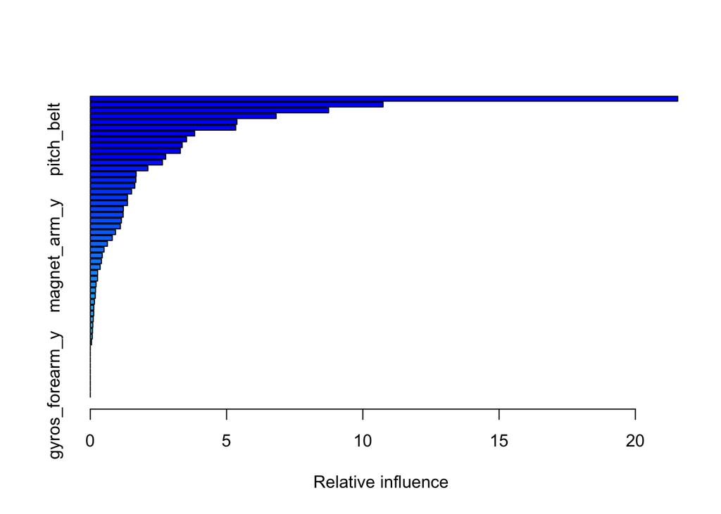

```r
tail(var_importance, 10)
```

```
##                               var   rel.inf
## yaw_forearm           yaw_forearm 0.0433138
## total_accel_belt total_accel_belt 0.0000000
## gyros_belt_x         gyros_belt_x 0.0000000
## accel_belt_x         accel_belt_x 0.0000000
## accel_belt_y         accel_belt_y 0.0000000
## total_accel_arm   total_accel_arm 0.0000000
## gyros_arm_z           gyros_arm_z 0.0000000
## yaw_dumbbell         yaw_dumbbell 0.0000000
## gyros_forearm_x   gyros_forearm_x 0.0000000
## gyros_forearm_y   gyros_forearm_y 0.0000000
```

Wow, there are a lot of predictors we’ve included in our model that have ZERO influence on its predictive power. Now if we look at the most influential variables:

```r
head(var_importance, 10)
```

```
##                                 var   rel.inf
## roll_belt                 roll_belt 21.554312
## pitch_forearm         pitch_forearm 10.741094
## yaw_belt                   yaw_belt  8.744687
## magnet_dumbbell_z magnet_dumbbell_z  6.817974
## magnet_dumbbell_y magnet_dumbbell_y  5.379152
## roll_forearm           roll_forearm  5.335931
## magnet_belt_z         magnet_belt_z  3.828128
## pitch_belt               pitch_belt  3.530724
## gyros_belt_z           gyros_belt_z  3.370707
## roll_dumbbell         roll_dumbbell  3.303008
```

We can see that just the top few variables — namely roll_belt, pitch_forearm, yaw_belt, and a few others, have by far the biggest influence on the model. If we wanted to in the future, we could try creating simpler multiple regression models to quantify the mean difference in these predictor variables between classes and get a more granular understanding of what constitutes “good” and “bad” weight-lifting form.